# Project 4

Visualising data about videos from the YouTube channels Shark Tank India and Shark Tank Global

Japekam Singh Dang

```css
body {
  font-size: 16px; /* Changing the default font size */
}
p {
  color: blue; /* Changing the text color to red */
}
h1, h2, h3 {
  font-weight: bold; /* Making headings bold */
}
```

## INTRODUCTION

The two channels I chose for my project were two Shark Tank channels: in particular, Shark Tank India, and Shark Tank Global). The reason I chose these channels is because, I am very interested in Shark Tank as a whole, it is one of my favourite shows to watch, and I was wondering if having just one region of the show made a difference to the YouTube Analytics generated, as compared to globally, and I wanted to use this project as an opportunity to explore that.

Challenge faced :

I also tried creating a bar chart showing whether the average view duration of a video is affected by its length, however, I realised it is rather obvious that it is pretty much directly correlated, and therefore, decided not to include it in my report. I realised I could not make any useful statistical inference out of this plot.

## DYNAMIC DATA STORY

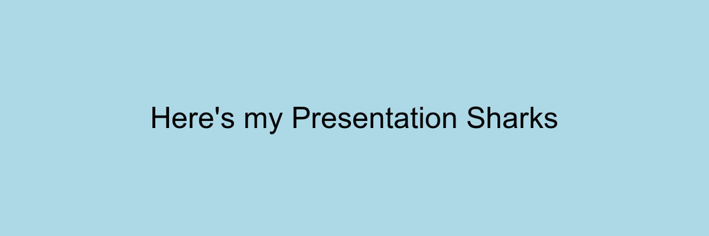

To show creativity, I used theme that sets the legend to none in my first plot. Apart from that, I also to quantify engagement, I simply added the comment and like count and tried to calculate engagement ration. I used functions like position, arrange, reorder, str_count. Also I tried to uncover a lot of questions which I had by creating 8-10 plots(but only displaying 5 here, which is much more than required). Apart from that, I used different colors, and kept my color theme as “lightcolors”, (I did use chatgpt to ask for some colors.) :)

## LEARNING REFLECTION

In the learning objectives for this Module, one of them was regarding the exploration of creating visualisations with ggplot2. Throughout this project, we created a lot of different types of plots with ggplot2, ranging from a histogram, to a scatter plot. Additionally, we used the labs within this to basically make our plots look good. I’m looking forward to ultimately seeing how much further I can go to make our plots look presentable, and learning more about what distinguishes a useful information plot from one that is not very statistically useful. I am also excited to start my introduction to SQL for the first time.

## APPENDIX

```r
library(tidyverse)
library(ggplot2)
library(stringr)

# Read the data from the CSV file
youtube_data <- read_csv("https://docs.google.com/spreadsheets/d/e/2PACX-1vTANyZ6SGGmp0wDIehlWgpyZ97MHBNPCeyR4TMmqA_s6miASA3CZwhIoIWXgrFsIPrwHsLAIb39Wl_J/pub?output=csv")

# Filter data for Shark Tank India and Shark Tank Global
shark_tank_india <- youtube_data %>%
  filter(channelName == "@SharkTankIndia")

shark_tank_global <- youtube_data %>%
  filter(channelName == "@SharkTankGlobal")

# Calculate average duration for each channel
avg_duration <- youtube_data %>%
  group_by(channelName) %>%
  summarise(avg_duration = mean(duration))

# Create a bar plot for average video duration comparison
avg_duration %>%
  ggplot() +
    geom_bar(aes(x = channelName, y = avg_duration, fill = channelName),
             stat = "identity", position = "dodge") +
    labs(title = "Average Video Duration Comparison",
        x = "Channel",
        y = "Average Duration (in minutes)") +
    theme_minimal() +
    theme(legend.position = "none")
ggsave("plot1.png", dpi = 100, width = 1200, height = 400, units = "px")

# Calculate engagement rate for each video
youtube_data1 <- youtube_data %>%
  mutate(engagement_rate = (likeCount + commentCount) / viewCount)

# Create a density plot for engagement comparison
youtube_data1 %>%
  ggplot() +
    geom_density(aes(x = engagement_rate, fill = channelName), alpha = 0.5) +
    labs(title = "Engagement Comparison",
        x = "Engagement Rate",
        y = "Density") +
    scale_fill_manual(values = c("@SharkTankIndia" = "blue", "@SharkTankGlobal" = "red")) +
    theme_minimal()
ggsave("plot2.png", dpi = 100, width = 1200, height = 400, units = "px")

# Sort data by likeCount for each channel
top_liked_per_channel <- youtube_data %>%
  group_by(channelName) %>%
  arrange(desc(likeCount))

# Create the histogram
top_liked_per_channel %>%
  ggplot() +
  geom_col(aes(x = reorder(title, likeCount), y = likeCount, fill = channelName),
           position = "dodge") +
  labs(title = "Top Liked Videos (Shark Tank India vs. Global)",
       x = "video title",  # No x-axis label
       y = "Like Count",
       fill = "Channel")
ggsave("plot3.png", dpi = 100, width = 1200, height = 400, units = "px")

# Number of views per video title length

youtube_data2 <- youtube_data %>%
  mutate(num_words = str_count(title, "\\S+"))

# Filter data for Shark Tank India and Shark Tank Global
shark_tank_india <- youtube_data2 %>%
  filter(channelName == "@SharkTankIndia")

shark_tank_global <- youtube_data2 %>%
  filter(channelName == "@SharkTankGlobal")

# Calculate view count per word of title for each channel
shark_tank_india <- shark_tank_india %>%
  mutate(views_per_word = viewCount / num_words)

shark_tank_global <- shark_tank_global %>%
  mutate(views_per_word = viewCount / num_words)

# Combine the filtered data frames
combined_data <- rbind(shark_tank_india, shark_tank_global)

# Create a scatter plot
combined_data %>%
  ggplot() +
    geom_point(aes(x = num_words, y = views_per_word, color = channelName), size = 3) +
    labs(title = "View Count per Word of Title Comparison",
        x = "Number of Words in Title", y = "Num of Views per Word") +
    scale_color_manual(values = c("@SharkTankIndia" = "blue", "@SharkTankGlobal" = "red"))
ggsave("plot4.png", dpi = 100, width = 1200, height = 400, units = "px")

# Filter for videos with at least 10 likes and 10 views (to avoid division by zero)
youtube_data3 <- youtube_data %>%
  filter(likeCount >= 10 & viewCount >= 10)

# Calculate like-to-view ratio
youtube_data3 <- youtube_data %>%
  mutate(like_view_ratio = likeCount / viewCount)

# Create a histogram
youtube_data3 %>%
  ggplot() +
    geom_histogram(aes(x = like_view_ratio, fill = channelName), bins = 30, color = "black", alpha = 0.7) +
    labs(title = "Distribution of Like to View Ratio",
        x = "Like to View Ratio", y = "Frequency") +
    scale_fill_manual(values = c("@SharkTankIndia" = "skyblue", "@SharkTankGlobal" = "salmon")) +
    theme_minimal()
ggsave("plot5.png", dpi = 100, width = 1200, height = 400, units = "px")
```

```r
library(magick)

my_colors <- c("lightblue", "lightgreen", "lightpink", "white", "lightgrey", "lightcoral", "lightyellow")

# Title slide
title_slide <- image_blank(color = my_colors[1], width = 1200, height = 400) %>%
  image_annotate(text = "Here's my Presentation Sharks", size = 50, gravity = "center")

# Visualization slides
plot1_slide <- image_read("plot1.png") %>%
  image_background(color = my_colors[2])

plot2_slide <- image_read("plot2.png") %>%
  image_background(color = my_colors[3])

plot3_slide <- image_read("plot3.png") %>%
  image_background(color = my_colors[4])

plot4_slide <- image_read("plot4.png") %>%
  image_background(color = my_colors[5])

plot5_slide <- image_read("plot5.png") %>%
  image_background(color = my_colors[6])

# Conclusion slide
conclusion_text <- "Overall, I learned that Shark Tank Global posts longer video on average compared to the Indian one. Their engagement ratio is far less than that of Shark Tank India. Most liked videos of Shark Tank India outnumbered the most liked video of Shark Tank global by a big margin. Shark Tank India sees a better result if they post more number of words in their title." %>%
  str_wrap(66)

conclusion_slide <- image_blank(color = my_colors[7], width = 1200, height = 400) %>%
  image_annotate(text = conclusion_text, size = 40, gravity = "center")

# Combine slides
frames <- c(rep(title_slide, 5), rep(plot1_slide, 5), rep(plot2_slide, 5), rep(plot3_slide, 5), rep(plot4_slide, 5), rep(plot5_slide, 5), rep(conclusion_slide, 5))
dynamic_data_story <- image_animate(frames, fps = 1)

image_write(dynamic_data_story, "data_story.gif")
```